# Proje Rapor : Ahmet Suat Kartal 210401134

# Q1 : Problem tanımı

Sigorta şirketimiz, müşteri kazalarının sıklığı nedeniyle istenilen kar hedeflerine ulaşamamaktadır. Kazaların sıklığı; müşterilerin dikkatsizliği, hava durumu ve yol koşulları gibi faktörlerin bir kombinasyonu nedeniyle artmakta, bu da kaza tazminat ödemelerinin artması gibi giderlere yol açarak şirketin karlılığını olumsuz yönde etkilemektedir. İşte bu rapor, şirketin karşılaştığı bu sorunu ele alarak çözmek üzere planlanan stratejiyi detaylandırmaktadır.

# Q2 : Proje Amacı

Bu proje, [US Accidents (2016 - 2023)](https://www.kaggle.com/datasets/sobhanmoosavi/us-accidents) veri setini kullanarak kazaların sıklıkla gerçekleştiği bölgeleri belirlemeyi ve bu bölgeleri müşterilerimize bildirerek, sürücülerin bu bölgelerde daha dikkatli olmaları ve kaza riskini azaltmalarını sağlamayı amaçlamaktadır. Bu projenin başarısı, şirketin karlılığını artırmanın yanı sıra, müşteri memnuniyetini ve trafik güvenliğini artırarak toplumsal fayda sağlayacaktır. Analizlerimizin, şirketin stratejik karar alma süreçlerine nasıl etki edeceğini ayrıntılı bir şekilde açıklayan bu rapor, projenin temel hedef ve etkilerini ortaya koymaktadır.

Projenin sonucunda elde edilecek sonuçlar, uygulamanın geliştirilmesinde önemli bir rol oynayacaktır. Örneğin, kazaların belirli zamanlarda veya bölgelerde daha yaygın olduğu belirlenirse, uygulama bu zamanlarda veya bölgelerde sürücüleri daha fazla uyaracak şekilde geliştirilebilir. Kazaların en yaygın nedenlerinin belirlenmesi de, uygulamanın bu nedenleri azaltmak için nasıl uyarlanabileceğinin belirlenmesine yardımcı olacaktır.

# Q3 : Veri seti keşifsel analizi

### Veri Seti Toplama Yöntemi

2016’dan 2023’e kadar olan dönemde ABD’deki trafik kazalarının bilgilerini içeren bu veri seti, [Kaggle](https://www.kaggle.com) veri paylaşım platformundan toplanmıştır.

### Veri Seti Yapısı

Veri seti, 7.73 milyondan fazla kayıt içeren 46 sütundan oluşmaktadır. Her bir satır, bir trafik kazasını temsil etmektedir ve sütunlar da aşağıdaki gibidir:

| Columns |
| --- |
| ID |
| Source |
| Severity |
| Start_Time |
| End_Time |
| Start_Lat |
| Start_Lng |
| End_Lat |
| End_Lng |
| Distance.mi. |

[output cut: 36 more lines]

Bu verilerin analizinde kullanılmasını beklediğimiz başlıca özellikler şunlardır:

- **Severity:** Kazanın şiddetini 1 (küçük) ile 4 (büyük) arasında bir sayı olarak sınıflandırır.
- **Start_Time & End_Time:** Kazanın başlangıç ve bitiş saatini ve tarihini belirtir, genellikle trafiğin kapanıp açılmasıyla ilişkilidir.
- **Start_Lat & Start_Lng:** Kazanın başlangıç noktasının enlem ve boylam koordinatlarını belirtir.
- **End_Lat & End_Lng:** Kazanın bitiş noktasının enlem ve boylam koordinatlarını belirtir.
- **Distance.mi.:** Kazanın başlangıç ve bitiş noktaları arasındaki mesafeyi mil cinsinden verir.
- **Street, City, State:** Kazanın meydana geldiği lokasyonu belirtir.
- **Weather_Timestamp & Weather_Condition:** Hava durumunu (örneğin, yağmurlu, karlı, açık) ve kaydedildiği saati belirtir.
- **Temperature.F.:** Kazanın meydana geldiği sıradaki sıcaklığı Fahrenheit cinsinden belirtir.
- **Bump, Crossing, Junction:** Kazanın yakınında tümsek, yaya geçidi ve kavşak, olup olmadığını belirtir.
- **Stop, Traffic_Calming, Traffic_Signal:** Kazanın yakınında stop işareti, trafik yavaşlatıcı ve trafik ışığı olup olmadığını belirtir.

Bahsi geçen bazı özellikleri gösteren veri setinin ön görsellemesi aşağıda verilmiştir:

| Severity | Start_Time | End_Time | Start_Lng | Start_Lat | City | State | Street | Weather_Condition | Bump | Crossing | Junction | Stop | Traffic_Calming | Traffic_Signal |
| --- | --- | --- | --- | --- | --- | --- | --- | --- | --- | --- | --- | --- | --- | --- |
| 3 | 2016-02-08 05:46:00 | 2016-02-08 11:00:00 | -84.05872 | 39.86515 | Dayton | OH | I-70 E | Light Rain | FALSE | FALSE | FALSE | FALSE | FALSE | FALSE |
| 2 | 2016-02-08 06:07:59 | 2016-02-08 06:37:59 | -82.83118 | 39.92806 | Reynoldsburg | OH | Brice Rd | Light Rain | FALSE | FALSE | FALSE | FALSE | FALSE | FALSE |
| 2 | 2016-02-08 06:49:27 | 2016-02-08 07:19:27 | -84.03261 | 39.06315 | Williamsburg | OH | State Route 32 | Overcast | FALSE | FALSE | FALSE | FALSE | FALSE | TRUE |
| 3 | 2016-02-08 07:23:34 | 2016-02-08 07:53:34 | -84.20558 | 39.74775 | Dayton | OH | I-75 S | Mostly Cloudy | FALSE | FALSE | FALSE | FALSE | FALSE | FALSE |
| 2 | 2016-02-08 07:39:07 | 2016-02-08 08:09:07 | -84.18835 | 39.62778 | Dayton | OH | Miamisburg Centerville Rd | Mostly Cloudy | FALSE | FALSE | FALSE | FALSE | FALSE | TRUE |
| 3 | 2016-02-08 07:44:26 | 2016-02-08 08:14:26 | -82.92519 | 40.10059 | Westerville | OH | Westerville Rd | Light Rain | FALSE | FALSE | FALSE | FALSE | FALSE | FALSE |
| 2 | 2016-02-08 07:59:35 | 2016-02-08 08:29:35 | -84.23051 | 39.75827 | Dayton | OH | N Woodward Ave | Overcast | FALSE | FALSE | FALSE | FALSE | FALSE | FALSE |
| 3 | 2016-02-08 07:59:58 | 2016-02-08 08:29:58 | -84.19490 | 39.77038 | Dayton | OH | N Main St | Overcast | FALSE | FALSE | FALSE | FALSE | FALSE | FALSE |
| 2 | 2016-02-08 08:00:40 | 2016-02-08 08:30:40 | -84.17200 | 39.77806 | Dayton | OH | Notre Dame Ave | Mostly Cloudy | FALSE | FALSE | FALSE | FALSE | FALSE | FALSE |
| 3 | 2016-02-08 08:10:04 | 2016-02-08 08:40:04 | -82.92519 | 40.10059 | Westerville | OH | Westerville Rd | Light Rain | FALSE | FALSE | FALSE | FALSE | FALSE | FALSE |

[output cut: 9990 more lines]

### Veri Seti Kalitesi

Veri seti, son derece kapsamlı ve genel olarak iyi kalitededir ve asağıdaki tabloda da görüldüğü üzere bu analiz sırasında incelenmesi planlanan sütunlarda geçersiz veri bulunmamaktadır.

```
##          Severity        Start_Time          End_Time         Start_Lng
##                 0                 0                 0                 0
##         Start_Lat              City             State            Street
##                 0                 0                 0                 0
## Weather_Condition              Bump          Crossing          Junction
##                 0                 0                 0                 0
##              Stop   Traffic_Calming    Traffic_Signal
##                 0                 0                 0
```

İncelenen veri setinde geçersiz veri yoktur ancak bazı eksik veriler bulunmaktadır. Örneğin **Weather_Condition** değeri olmayan 173459 tane veri bulunmuştur, bu da kaza gününe ait elimizde hava durumu verisi olmadığını gösterir. Benzer şekilde **City** değeri olmayan 253 ve **Street** değeri olmayan 10869 tane veri bulunmuştur. Bu sayılar fazlaymış gibi görünse de veri seti çok büyük olduğu için bu eksiklikler de görmezden gelinebilir seviyelerdedir.

### Grafikler

- **Eyaletlere göre kaza sayısı**

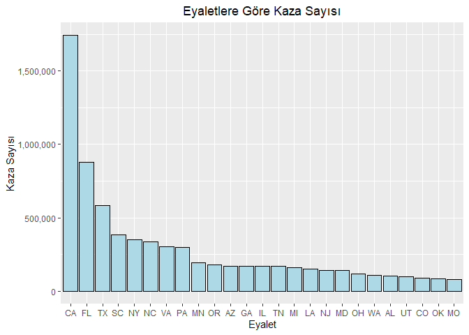

Yukarıdaki grafikte Amerika’nın en büyük 25 eyaleti kaza sayılarına göre sıralanmıştır. En yüksek kaza sayısına sahip California’yı, şirketimizin kurulduğu eyalet olan Teksas’ı ve grafikteki en az kazaya sahip iki eyalet olan Oklahoma ve Missouri’yi daha detaylı inceleyelim.

- **Eyaletlerdeki Kazaların Şiddete Göre Dağılımı**

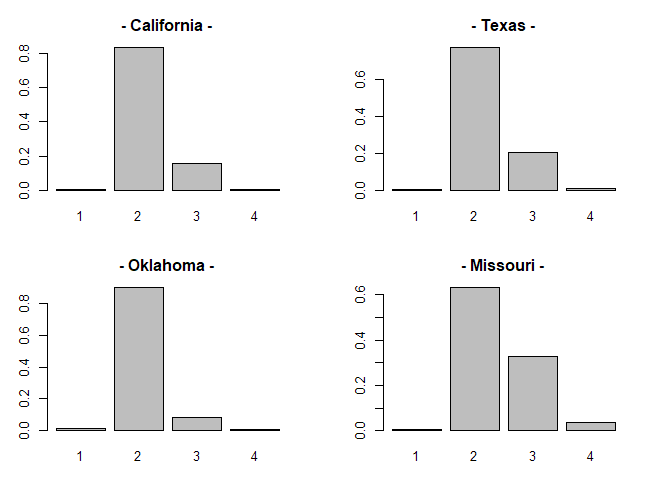

- California’nın en çok kaza olan eyalet olduğunu görüyoruz. Bu, California’nın nüfus yoğunluğunun yüksek olması ve trafik akışının yoğun olmasından kaynaklanıyor olabilir.
- Şiddet derecesi (severity) 2 olan kazaların her eyalette en yaygın kaza türü olduğunu görüyoruz. Bu, hafif kazaların trafikte en yaygın kaza türü olduğu anlamına geliyor.
- Missouri’nin şiddet derecesi (severity) 3 ve 4 kazalarda diğer eyaletlerden daha yüksek bir orana sahip olduğunu görüyoruz. Bu, Missouri’nin yol koşullarının daha kötü olmasından veya sürücü davranışlarının daha riskli olmasından kaynaklanıyor olabilir.
- Teksas’ın şiddet derecesi (severity) 3 kazalarda California’ya göre daha yüksek bir orana sahip olduğunu görüyoruz. Bu, Teksas’ın nüfus yoğunluğunun California’ya göre daha düşük olmasından kaynaklanıyor olabilir.

Daha herhangi bir sonuca varmak için çok erken olsa da, elimizdeki verilerin yüzeysel incelenmesinden yola çıkarak aşağıdaki çıkarımları yapabiliriz:

- California’da trafik güvenliğini iyileştirmek için, trafik akışının yoğun olduğu bölgelerde trafik kontrol önlemleri artırılabilir.
- Missouri’de trafik güvenliğini iyileştirmek için, yol koşullarının iyileştirilmesi ve sürücü davranışlarının iyileştirilmesi için eğitim ve denetim çalışmaları yapılabilir.
- Teksas’da trafik güvenliğini iyileştirmek için, nüfus yoğunluğunun düşük olduğu bölgelerde trafik güvenliği farkındalığının artırılması için çalışmalar yapılabilir.

### İstatistikler

# Q4 : Veri seti ön işlemesi

**Analize Dahil Edilmeyen Veriler**

Elimizdeki veri setinin sahip olduğu sütunlar aşağıdaki gibidir:

| Columns |
| --- |
| ID |
| Source |
| Severity |
| Start_Time |
| End_Time |
| Start_Lat |
| Start_Lng |
| End_Lat |
| End_Lng |
| Distance.mi. |

[output cut: 36 more lines]

Görüldüğü üzere buradaki özelliklerin birçoğunun projeye gerçekçi bir katkı sağlaması mümkün değildir ve bu sütunlar veri analizine dahil edilmeyecektir. Aşağıda birkaçı nedenleriyle birlikte listelenmiştir:

- **ID**, her bir kazayı temsil eden özgün bir değer olduğu için ve kaza şiddeti hakkında anlamlı bilgiler sağlamadığı için çıkartılmıştır.
- **Source**, kaza raporunu yapan şirketi veya grubu belirtir, ancak kaza şiddetini bulmak için anlamlı değildir, bu nedenle çıkartılmıştır.
- **End_Lat** ve **End_Lng** çoğunlukla null değerleri içeriyordur veya anlamlı değildir, bu nedenle çıkartılmıştır.
- **Description**, temel olarak kazaların şeklini özetler, her kaza için farklıdır ve analizi yapılamaz, bu nedenle çıkartılmıştır.
- **Weather_Timestamp**, hava koşullarının ne zaman rapor edildiğini belirtir ancak kaza şiddetini belirlemede anlamlı değildir, bu nedenle çıkartılmıştır.
- **Wind_direction**, kaza rapor edildiğindeki rüzgarın genel yönünü gösterir ancak bu analiz için anlamlı değildir, bu nedenle çıkartılmıştır.
- **Civil_Twilight, Nautical_Twilight, Astronomical_Twilight** ve **Sunrise_Sunset**, kazaların meydana geldiği günün saatini açıklamak için kullanılan yöntemlerdir. Bu değerler üzerinden analiz yapmak mümkün olsa da saati ve tarihi gösteren başka bir veri olduğu için bu 4 sütun gereksiz bulunmuş, bu nedenle çıkartılmıştır.

**Veri Setinden Silinen Veriler**

Veri Seti kalite analizi yapılırken toplam 184581 tane satırda eksik veri tespit edilmişti; bu satırlar temizlendi.

**Değiştirilen Veri Tipleri**

Faktör (factor) tipi: Sınırlı sayıda farklı değere sahip kategorik değişkenler için kullanılır. Bu, modellerin kategorik değişkenleri daha iyi anlamasına ve daha doğru tahminler yapmasına olanak tanır. Bu nedenle bazı verilerin tipi *Factor* olarak değiştirilmiştir.

- **Severity**: Sınırlı sayıda farklı değere sahip olduğu için *int* yerine *factor* olarak değiştirildi.
- **State** ve **City**: Eyalet adları kategorik değişken olduğu için *chr* yerine *factor* olarak değiştirildi.
- **Weather_Condition**: Hava durumu değişkeni kategorik olduğu için *chr* yerine *factor* olarak değiştirildi.

Bu değişimlerden sonra veri seti aşağıdaki gibidir:

| Severity | Start_Time | End_Time | Start_Lng | Start_Lat | City | State | Street | Weather_Condition | Bump | Crossing | Junction | Stop | Traffic_Calming | Traffic_Signal |
| --- | --- | --- | --- | --- | --- | --- | --- | --- | --- | --- | --- | --- | --- | --- |
| 3 | 2016-02-08 05:46:00 | 2016-02-08 11:00:00 | -84.05872 | 39.86515 | Dayton | OH | I-70 E | Light Rain | FALSE | FALSE | FALSE | FALSE | FALSE | FALSE |
| 2 | 2016-02-08 06:07:59 | 2016-02-08 06:37:59 | -82.83118 | 39.92806 | Reynoldsburg | OH | Brice Rd | Light Rain | FALSE | FALSE | FALSE | FALSE | FALSE | FALSE |
| 2 | 2016-02-08 06:49:27 | 2016-02-08 07:19:27 | -84.03261 | 39.06315 | Williamsburg | OH | State Route 32 | Overcast | FALSE | FALSE | FALSE | FALSE | FALSE | TRUE |
| 3 | 2016-02-08 07:23:34 | 2016-02-08 07:53:34 | -84.20558 | 39.74775 | Dayton | OH | I-75 S | Mostly Cloudy | FALSE | FALSE | FALSE | FALSE | FALSE | FALSE |
| 2 | 2016-02-08 07:39:07 | 2016-02-08 08:09:07 | -84.18835 | 39.62778 | Dayton | OH | Miamisburg Centerville Rd | Mostly Cloudy | FALSE | FALSE | FALSE | FALSE | FALSE | TRUE |
| 3 | 2016-02-08 07:44:26 | 2016-02-08 08:14:26 | -82.92519 | 40.10059 | Westerville | OH | Westerville Rd | Light Rain | FALSE | FALSE | FALSE | FALSE | FALSE | FALSE |
| 2 | 2016-02-08 07:59:35 | 2016-02-08 08:29:35 | -84.23051 | 39.75827 | Dayton | OH | N Woodward Ave | Overcast | FALSE | FALSE | FALSE | FALSE | FALSE | FALSE |
| 3 | 2016-02-08 07:59:58 | 2016-02-08 08:29:58 | -84.19490 | 39.77038 | Dayton | OH | N Main St | Overcast | FALSE | FALSE | FALSE | FALSE | FALSE | FALSE |
| 2 | 2016-02-08 08:00:40 | 2016-02-08 08:30:40 | -84.17200 | 39.77806 | Dayton | OH | Notre Dame Ave | Mostly Cloudy | FALSE | FALSE | FALSE | FALSE | FALSE | FALSE |
| 3 | 2016-02-08 08:10:04 | 2016-02-08 08:40:04 | -82.92519 | 40.10059 | Westerville | OH | Westerville Rd | Light Rain | FALSE | FALSE | FALSE | FALSE | FALSE | FALSE |

**Sonuç**

Veri seti ön işleme işlemleri sonucunda, veri seti analize hazır hale getirilmiştir. Eksik veriler temizlenmiş, sayısal değerler doğru formata dönüştürülmüş ve kategorik değerler faktör tipine dönüştürülmüştür.

# Q5 : Veri mühendisliği

| Severity | Start_Time | End_Time | Start_Lng | Start_Lat | City | State | Street | Weather_Condition | Bump | Crossing | Junction | Stop | Traffic_Calming | Traffic_Signal | company_loss |
| --- | --- | --- | --- | --- | --- | --- | --- | --- | --- | --- | --- | --- | --- | --- | --- |
| 3 | 2016-02-08 05:46:00 | 2016-02-08 11:00:00 | -84.05872 | 39.86515 | Dayton | OH | I-70 E | Light Rain | FALSE | FALSE | FALSE | FALSE | FALSE | FALSE | FALSE |
| 2 | 2016-02-08 06:07:59 | 2016-02-08 06:37:59 | -82.83118 | 39.92806 | Reynoldsburg | OH | Brice Rd | Light Rain | FALSE | FALSE | FALSE | FALSE | FALSE | FALSE | FALSE |
| 2 | 2016-02-08 06:49:27 | 2016-02-08 07:19:27 | -84.03261 | 39.06315 | Williamsburg | OH | State Route 32 | Overcast | FALSE | FALSE | FALSE | FALSE | FALSE | TRUE | FALSE |
| 3 | 2016-02-08 07:23:34 | 2016-02-08 07:53:34 | -84.20558 | 39.74775 | Dayton | OH | I-75 S | Mostly Cloudy | FALSE | FALSE | FALSE | FALSE | FALSE | FALSE | TRUE |
| 2 | 2016-02-08 07:39:07 | 2016-02-08 08:09:07 | -84.18835 | 39.62778 | Dayton | OH | Miamisburg Centerville Rd | Mostly Cloudy | FALSE | FALSE | FALSE | FALSE | FALSE | TRUE | TRUE |
| 3 | 2016-02-08 07:44:26 | 2016-02-08 08:14:26 | -82.92519 | 40.10059 | Westerville | OH | Westerville Rd | Light Rain | FALSE | FALSE | FALSE | FALSE | FALSE | FALSE | FALSE |
| 2 | 2016-02-08 07:59:35 | 2016-02-08 08:29:35 | -84.23051 | 39.75827 | Dayton | OH | N Woodward Ave | Overcast | FALSE | FALSE | FALSE | FALSE | FALSE | FALSE | FALSE |
| 3 | 2016-02-08 07:59:58 | 2016-02-08 08:29:58 | -84.19490 | 39.77038 | Dayton | OH | N Main St | Overcast | FALSE | FALSE | FALSE | FALSE | FALSE | FALSE | TRUE |
| 2 | 2016-02-08 08:00:40 | 2016-02-08 08:30:40 | -84.17200 | 39.77806 | Dayton | OH | Notre Dame Ave | Mostly Cloudy | FALSE | FALSE | FALSE | FALSE | FALSE | FALSE | FALSE |
| 3 | 2016-02-08 08:10:04 | 2016-02-08 08:40:04 | -82.92519 | 40.10059 | Westerville | OH | Westerville Rd | Light Rain | FALSE | FALSE | FALSE | FALSE | FALSE | FALSE | FALSE |

[output cut: 40 more lines]

**Yeni Sütun Oluşturma**

Şirketin kullanıcı veri tabanına analiz sırasında erişim sağlanamadığı için, bu eksikliği şimdilik kapatması adına, US Accidents veri setine yeni, **sentetik**, bir sütun eklendi. Bu sütun, bir kazanın şirketi etkileyip etkilemediğini gösteren bir değişkendir. Eklenen verilerin sonucu olarak, veri setindeki kazaların %20’sinin şirketin maddi zarar görmesine neden olduğu gözlemlenmektedir. Gerçek kullanıcı veri tabanı analize hazır hale geldiği zaman bu veri setiyle birleştirilip daha spesifik ve gerçek sonuçlar elde edilebilir.

# Q6 : Veri analizi

- **Zamana göre kaza sayısı**

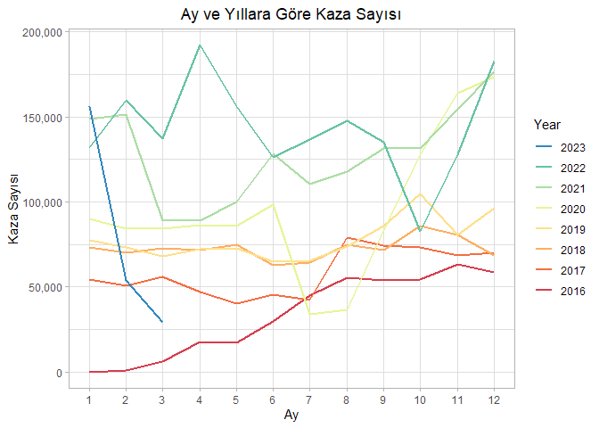

Grafik incelendiğinde 2020 yılının sonlarında kaza sayısında büyük bir artış olduğu gözlemlenmiştir. Bu tarihten önceki ve sonraki kazalar arasında olan dramatik farka bakılırsa bu artış, bazı veri kaynaklarından aniden daha fazla veri toplanması ve raporlanmasından kaynaklanmış gibi görünüyor. Yine 2020 yılının Temmuz ve Ağustos aylarındaki kaza sayısındaki düşüşün nedeni ise belirsiz; ancak bu durum, o sene etkisini gösteren Covid salgını ve o dönemde daha az insanın yolda olmasıyla ilişkili olabilir.

- 2020 yılında kaza raporlarında ciddi bir artış gözlemlenmiştir.
- En çok kaza 2022 yılında raporlara geçmiştir.

Analize daha spesifik bir bölge üzerinden *(Maryland)* ve daha dar bir zaman aralığında *(2023 yılından itibaren)* devam edelim.

- **Konuma Göre Kaza Şiddet Grafiği**

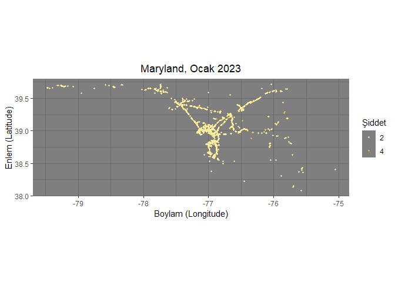

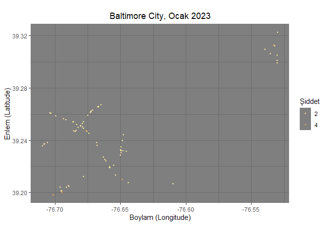

Bu görselleme, **Maryland** eyaletindeki kazaların konumlarını incelemekte olup, kazaların şiddet seviyelerini renk kullanarak göstermektedir. İlk grafik eyaletin genelini kapsarken, ikinci grafik genel olarak **Baltimore City**’nin konumuna odaklanmaktadır. Beklendiği gibi, daha ciddi kazalar genellikle ana otoyollarda meydana gelmektedir; bu durum, muhtemelen araçların daha yüksek hız yapmasından dolayıdır. Baltimore City içerisinde ise, çoğu kaza genellikle şehre giden ve şehirden çıkan otoyollar üzerinde meydana gelmektedir.

**Maryland**, nispeten küçük bir eyalet olmasına rağmen, bu bölgede yüksek sayıda kaza raporu ile karşılaşılmıştır. Bu durum, muhtemelen Maryland’in **Washington DC**’ye olan yakınlığı ve eyaleti geçen birçok karayolun etkisiyle ilişkilendirilebilir. **Maryland** içinde gerçekleşen kazaların çoğu 2. seviyede olup, genellikle soğuk, bulutlu, hafif yağmurlu veya fırtınalı hava koşullarında meydana gelmektedir. Daha ciddi kazalar ise genellikle daha yüksek hız sınırlarına sahip otoyollar ve yollar üzerinde gerçekleşmektedir.

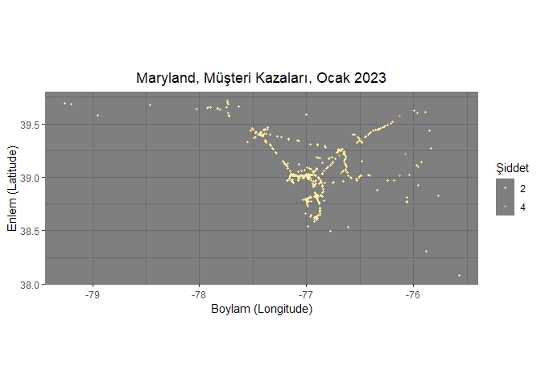

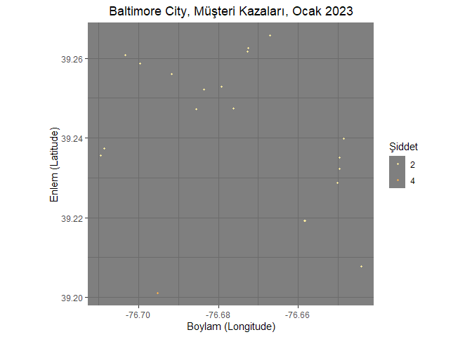

- **Belirleyici Yol Özelliklerine Göre Kaza Grafiği**

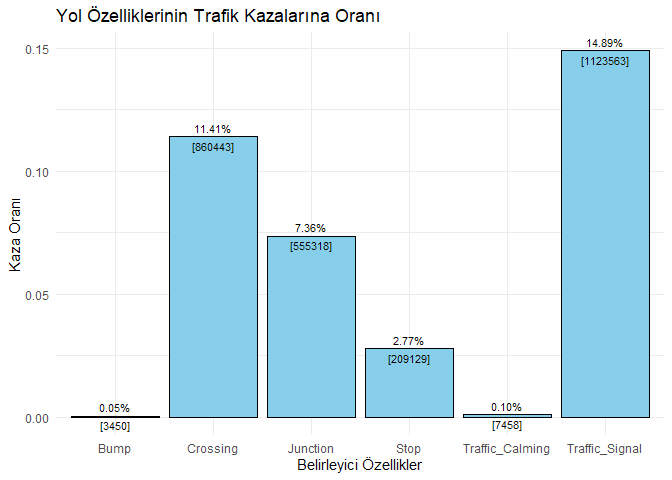

**Genel Değerlendirme ve Öneriler:**

Trafik güvenliği önlemleri, özellikle yaya geçitleri, trafik sinyalleri ve kavşaklarda yoğunlaştırılmalıdır. Kazaların az olduğu bölgelerde dahi, önleyici tedbirlerin alınması ve sürücülerin bilinçlendirilmesi önemlidir. Müşterilerin, özellikle yoğun kazaların olduğu bölgelerde uyarılması gerekmektedir. Bu çıkarımlar, projedeki trafik güvenliği önlemlerinin etkili bir şekilde planlanması ve uygulanması için rehberlik edebilir. Ancak, yerel koşullar ve spesifik durumlar göz önüne alınarak daha ayrıntılı bir analiz yapmak, ve bu verileri diğer verilerle karşılaştırmak her zaman faydalı olacaktır. Yine de şimdilik bu veriler üzerinde tatmin edici çıkarımlar yapılmıştır.

- **Yüzdelik Kaza - Saat Grafiği**

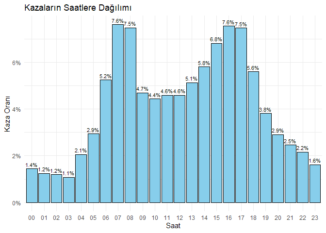

Gün içinde en yüksek kaza sıklığı, özellikle saat 7-8 arası ve 15-17 arasında gözlemlenmiştir. Bu saat dilimlerinde toplam kaza sayısının yüksek olmasının, yaklaşık olarak iş saatlerine denk gelmesi dikkat çekicidir. Bu saatlerde trafik yoğunluğunun artması, sürücülerin aceleyle hareket etmelerine ve kaza riskini artırmalarına neden olabilir. Proje kapsamında müşterilerin uyarılmasını gerektirecek veriler analiz edilirken bu grafikten de çıkarımlar yapılabilir.

# Q7 : Sonuç değerlendirme, tavsiyeler

Proje genelinde yapılan operasyonlar, veri setinin temizlenmesi ve analiz edilmesi için kullanılan yöntemler açısından geçerlidir. Veri seti, eksik veya tutarsız verilerden temizlenmiştir. Analiz, doğru istatistiksel yöntemler kullanılarak gerçekleştirilmiştir.

**Bulunan Sonuçlar**

Bulunan sonuçlar, projenin ana problemini çözmeye yardımcı olacak önemli bilgiler sağlamaktadır. Örneğin, kazaların hangi yol özelliklerinde daha sık meydana geldiğini belirlemek, kazaları azaltmak için önlemler almak için değerli bilgiler sağlayabilir.

Örneğin, trafik sinyali yakınlarında meydana gelen kazaların daha yaygın olduğunun belirlenmesi, trafik sinyali yakınlarında daha dikkatli sürüş eğitimi verilmesi gerektiği fikrini desteklemektedir.

**Analiz ve Sonuçların Kuvvetli ve Zayıf Yönleri**

Analiz ve sonuçların güçlü yönleri şunlardır:

- Veri seti, eksik veya tutarsız verilerden temizlenmiştir.
- Çok kapsamlı veriler üzerinde çalışılmıştır.
- Analiz, doğru istatistiksel yöntemler kullanılarak gerçekleştirilmiştir.
- Sonuçlar, projenin ana problemini çözmeye yardımcı olacak önemli bilgiler sağlamaktadır.

Analiz ve sonuçların zayıf yönleri şunlardır:

- Analizde müşteri veritabanı gibi gerçek şirket verileri de kullanılabilirdi ve daha tutarlı sonuçlar elde edilebilirdi.
- Analiz, daha fazla istatistik ve grafik içerebilirdi. Elde edilen grafikler diğer verilerle de karşılaştırılıp daha kesin ve spesifik bilgiler elde edilebilirdi. Bu da müşteriler için planladığımız mobil uygulamada daha tutarlı ve yerinde analizler yaparak projenin başarı oranını artırabilirdi. Ancak zaman darlığı sebebiyle çok kapsamlı bir analiz yapılamadı.

**Sonuç Olarak**

Bu proje kapsamında, araç kazalarının trafik müdahalesi ile ilişkili faktörlerini anlamak için daha fazla bilgiye ve analize ihtiyaç olduğu sonucuna varılmıştır.

Ayrıca, bu veri setindeki eksik değerlerin daha iyi tanımlanması gerekmektedir. Özellikle, değişkenlerde birçok NA değeri bulunmaktadır ve bu yüzden analize dahil bile edilmemişlerdir.

Bunun yanı sıra, araç kazalarının trafik müdahalesine neden olan diğer potansiyel faktörleri ve hangi faktörlerin en önemli olduğunu belirleme yöntemlerini daha ayrıntılı bir şekilde incelememiz gerekmektedir.

Sonuç olarak, bu projenin bulgularının daha fazla araştırma ve detaylı analizlere dayanarak güçlendirilmesi, gelecekteki çalışmalara rehberlik etmesi önemlidir. Elde edilen sonuçlar, trafik güvenliği konusundaki stratejilerin daha etkili bir şekilde geliştirilmesi ve uygulanması için temel oluşturabilir ve bu haliyle bile müşterilerin daha az kazaya karışmasını sağlayacak veriler elde edilebilir. Yine de bunun dramatik bir fark yaratabilmesi için daha detaylı verilere ve analizlere ihtiyaç vardır.